# Q1b

```r
library(sf); library(spdep); library(spatialreg); library(tmap)
```

```r
# Load the shapefile for Italian regions
italy <- st_read("italy.shp")
italy
```

```
## Simple feature collection with 20 features and 1 field
## Geometry type: MULTIPOLYGON
## Dimension:     XY
## Bounding box:  xmin: 4055456 ymin: 1422800 xmax: 5047056 ymax: 2665352
## Projected CRS: ETRS89-extended / LAEA Europe
## First 10 features:
##                   REGION                       geometry
## 1               Sardinia MULTIPOLYGON (((4299705 195...
## 2                 Veneto MULTIPOLYGON (((4530306 261...
## 3  Friuli Venezia Giulia MULTIPOLYGON (((4600801 252...
## 4         Emilia Romagna MULTIPOLYGON (((4285438 244...
## 5                Tuscany MULTIPOLYGON (((4358646 234...
## 6                 Umbria MULTIPOLYGON (((4545500 226...
## 7                 Marche MULTIPOLYGON (((4542187 232...
## 8                 Latium MULTIPOLYGON (((4526488 214...
## 9               Calabria MULTIPOLYGON (((4927897 184...
## 10                Sicily MULTIPOLYGON (((4787072 165...
```

```r
# Load the fertility data
fertility <- read.csv("Fertility2011.csv")
fertility
```

```
##                   Region Fertility.rate Employment.rate Unemployment.rate GDP.growth.rate
## 1               Piedmont           1.45            64.2               7.6           -0.46
## 2           Aosta Valley           1.60            66.9               5.3           -1.14
## 3               Lombardy           1.53            64.6               5.7           -0.84
## 4    Trentino Alto Adige           1.62            68.4               3.9           -0.23
## 5                 Veneto           1.48            64.9               4.9            0.17
## 6  Friuli Venezia Giulia           1.38            64.2               5.2           -0.84
## 7                Liguria           1.34            63.0               6.4           -0.58
## 8         Emilia Romagna           1.50            67.8               5.2            0.74
## 9                Tuscany           1.40            63.6               6.3           -0.54
## 10                Umbria           1.40            62.2               6.4           -1.85
## 11                Marche           1.42            62.4               6.8           -1.53
## 12                Latium           1.48            58.8               8.7           -1.07
## 13               Abruzzo           1.35            56.6               8.6            1.05
## 14                Molise           1.19            50.3               9.9           -3.07
## 15              Campania           1.43            39.4              15.4           -2.55
## 16                Puglia           1.32            44.7              13.2           -1.27
## 17            Basilicata           1.19            47.6              11.9           -0.20
## 18              Calabria           1.30            42.4              12.7           -2.36
## 19                Sicily           1.42            42.4              14.3           -2.72
## 20              Sardinia           1.44            51.7              13.5           -1.53
```

```r
# Ensure both datasets have a common key to join on
# Assuming "REGION" in `italy` matches a column in `fertility`
# You might need to change "RegionName" to the actual column name in `fertility` if different
colnames(fertility)[1] <- "REGION"  # Update column name if necessary

# Merge the datasets
fertility_spatial <- merge(italy, fertility, by = "REGION")
fertility_spatial
```

```
## Simple feature collection with 20 features and 5 fields
## Geometry type: MULTIPOLYGON
## Dimension:     XY
## Bounding box:  xmin: 4055456 ymin: 1422800 xmax: 5047056 ymax: 2665352
## Projected CRS: ETRS89-extended / LAEA Europe
## First 10 features:
##                   REGION Fertility.rate Employment.rate Unemployment.rate GDP.growth.rate
## 1                Abruzzo           1.35            56.6               8.6            1.05
## 2           Aosta Valley           1.60            66.9               5.3           -1.14
## 3             Basilicata           1.19            47.6              11.9           -0.20
## 4               Calabria           1.30            42.4              12.7           -2.36
## 5               Campania           1.43            39.4              15.4           -2.55
## 6         Emilia Romagna           1.50            67.8               5.2            0.74
## 7  Friuli Venezia Giulia           1.38            64.2               5.2           -0.84
## 8                 Latium           1.48            58.8               8.7           -1.07
## 9                Liguria           1.34            63.0               6.4           -0.58
## 10              Lombardy           1.53            64.6               5.7           -0.84
##                          geometry
## 1  MULTIPOLYGON (((4695183 208...
## 2  MULTIPOLYGON (((4155108 253...
## 3  MULTIPOLYGON (((4849351 199...
## 4  MULTIPOLYGON (((4927897 184...
## 5  MULTIPOLYGON (((4688170 204...
## 6  MULTIPOLYGON (((4285438 244...
## 7  MULTIPOLYGON (((4600801 252...
## 8  MULTIPOLYGON (((4526488 214...
## 9  MULTIPOLYGON (((4257616 238...
## 10 MULTIPOLYGON (((4386364 252...
```

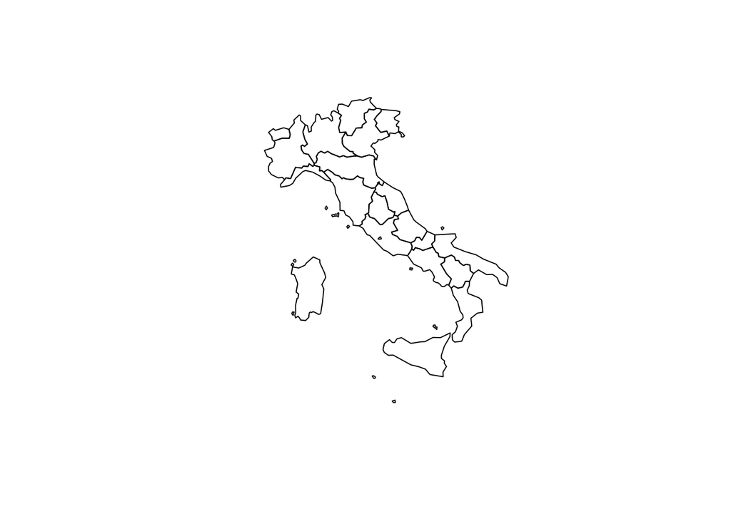

```r
plot(st_geometry(fertility_spatial))
```

```r
# Check validity of each geometry
validity_check <- st_is_valid(fertility_spatial)

# Print the validity results
validity_check
```

```
##  [1] TRUE TRUE TRUE TRUE TRUE TRUE TRUE TRUE TRUE TRUE TRUE TRUE TRUE TRUE TRUE TRUE TRUE
## [18] TRUE TRUE TRUE
```

```r
# If there are invalid geometries, we can attempt to make them valid using st_make_valid()
if (any(!validity_check)) {
  fertility_spatial <- st_make_valid(fertility_spatial)
  print("Some geometries were invalid and have been corrected.")
}

# Check validity again after correction
validity_check_after <- st_is_valid(fertility_spatial)
validity_check_after
```

```
##  [1] TRUE TRUE TRUE TRUE TRUE TRUE TRUE TRUE TRUE TRUE TRUE TRUE TRUE TRUE TRUE TRUE TRUE
## [18] TRUE TRUE TRUE
```

```r
# Set tmap mode to "plot" for static maps (use "view" for interactive maps)
tmap_mode("plot")
```

```
## tmap mode set to plotting
```

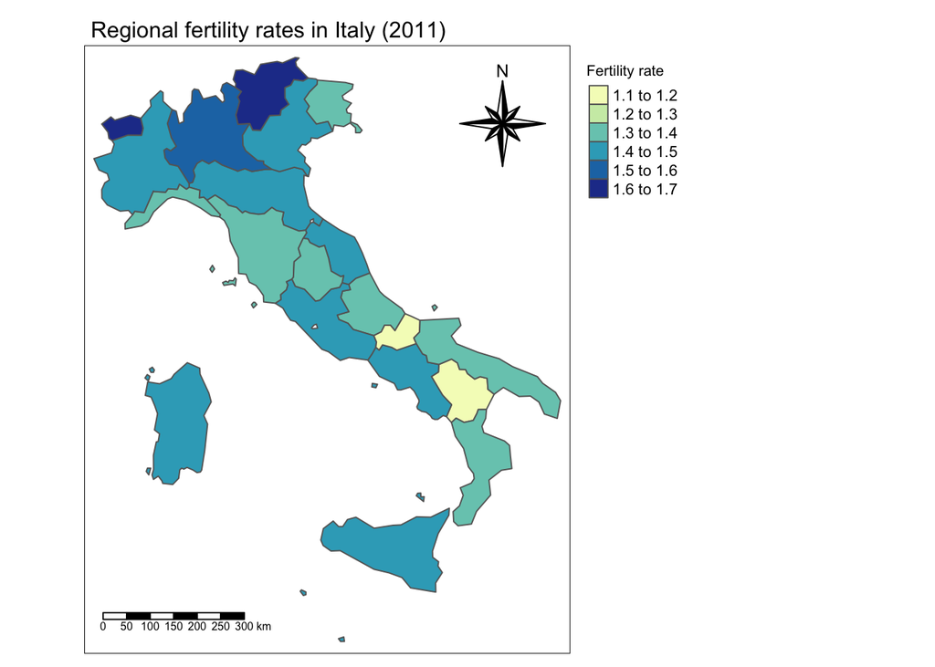

```r
# Plot the fertility rates
tm_shape(fertility_spatial) +
  tm_polygons("Fertility.rate",
              palette = "YlGnBu", # iii. Change color palette
              title = "Fertility rate") +
  tm_scale_bar(position = c("left", "bottom")) + # i. Add scale bar
  tm_compass(type = "8star", position = c("right", "top")) + # ii. Add north arrow
  tm_layout(main.title = "Regional fertility rates in Italy (2011)",
            main.title.size = 1,          # Decrease main title font size
            legend.title.size = 0.8,      # Decrease legend title font size
            legend.text.size = 0.7,       # Decrease legend text font size
            legend.outside = TRUE)
```

```r
# i.
# Regress fertility rate on all other variables
full_model <- lm(Fertility.rate ~ Employment.rate + Unemployment.rate + GDP.growth.rate, data = fertility_spatial)
summary(full_model)
```

```
##
## Call:
## lm(formula = Fertility.rate ~ Employment.rate + Unemployment.rate +
##     GDP.growth.rate, data = fertility_spatial)
##
## Residuals:
##       Min        1Q    Median        3Q       Max
## -0.156509 -0.053520 -0.002533  0.062869  0.155167
##
## Coefficients:
##                    Estimate Std. Error t value Pr(>|t|)
## (Intercept)       -0.111986   0.693328  -0.162   0.8737
## Employment.rate    0.020981   0.008759   2.395   0.0292 *
## Unemployment.rate  0.035314   0.022371   1.579   0.1340
## GDP.growth.rate   -0.017444   0.024130  -0.723   0.4802
## ---
## Signif. codes:  0 '***' 0.001 '**' 0.01 '*' 0.05 '.' 0.1 ' ' 1
##
## Residual standard error: 0.09202 on 16 degrees of freedom
## Multiple R-squared:  0.4405, Adjusted R-squared:  0.3355
## F-statistic: 4.198 on 3 and 16 DF,  p-value: 0.02271
```

```r
# ii.
# Stepwise elimination of non-significant variables
sub_model <- step(full_model, direction = "backward")
```

```
## Start:  AIC=-91.89
## Fertility.rate ~ Employment.rate + Unemployment.rate + GDP.growth.rate
##
##                     Df Sum of Sq     RSS     AIC
## - GDP.growth.rate    1  0.004425 0.13990 -93.251
## <none>                           0.13548 -91.894
## - Unemployment.rate  1  0.021099 0.15657 -90.999
## - Employment.rate    1  0.048583 0.18406 -87.765
##
## Step:  AIC=-93.25
## Fertility.rate ~ Employment.rate + Unemployment.rate
##
##                     Df Sum of Sq     RSS     AIC
## <none>                           0.13990 -93.251
## - Unemployment.rate  1  0.019652 0.15955 -92.622
## - Employment.rate    1  0.044203 0.18410 -89.760
```

Comment: Using a stepwise selection approach, the variable GDP.growth.rate was identified as not contributing significantly to explaining variations in the fertility rate. Removing it resulted in a reduced model that includes only Employment.rate and Unemployment.rate. This sub-model was chosen based on minimising the AIC (Akaike Information Criterion), which suggests that the reduced model offers a better trade-off between model complexity and goodness-of-fit.

```r
# iii.
summary(sub_model)
```

```
##
## Call:
## lm(formula = Fertility.rate ~ Employment.rate + Unemployment.rate,
##     data = fertility_spatial)
##
## Residuals:
##      Min       1Q   Median       3Q      Max
## -0.14738 -0.05091 -0.01742  0.05440  0.15382
##
## Coefficients:
##                   Estimate Std. Error t value Pr(>|t|)
## (Intercept)       0.016697   0.660610   0.025   0.9801
## Employment.rate   0.019255   0.008308   2.318   0.0332 *
## Unemployment.rate 0.033963   0.021978   1.545   0.1407
## ---
## Signif. codes:  0 '***' 0.001 '**' 0.01 '*' 0.05 '.' 0.1 ' ' 1
##
## Residual standard error: 0.09072 on 17 degrees of freedom
## Multiple R-squared:  0.4222, Adjusted R-squared:  0.3542
## F-statistic: 6.211 on 2 and 17 DF,  p-value: 0.009445
```

```r
# Create spatial weights list from the neighbour file
it_nb <- read.gal("italy.gal")
it_lw <- nb2listw(it_nb, style = "W")

# Run spatial regression models

# Spatial Autoregressive Model (SAR)
fertility_SAR <- spautolm(Fertility.rate ~ 1, data = fertility_spatial, listw = it_lw)
fertility_SAR
```

```
##
## Call:
## spautolm(formula = Fertility.rate ~ 1, data = fertility_spatial,
##     listw = it_lw)
##
## Coefficients:
## (Intercept)      lambda
##   1.4182681  -0.5431573
##
## Log likelihood: 17.41134
```

```r
# Spatial Lag Model (SLM)
fertility_SLM <- lagsarlm(Fertility.rate ~ Employment.rate + Unemployment.rate, data = fertility_spatial, listw = it_lw)
fertility_SLM
```

```
##
## Call:
## lagsarlm(formula = Fertility.rate ~ Employment.rate + Unemployment.rate,
##     data = fertility_spatial, listw = it_lw)
## Type: lag
##
## Coefficients:
##               rho       (Intercept)   Employment.rate Unemployment.rate
##       -0.34122291        0.62919474        0.01744900        0.03150362
##
## Log likelihood: 22.04878
```

```r
# Spatial Error Model (SEM)
fertility_SEM <- errorsarlm(Fertility.rate ~ Employment.rate + Unemployment.rate, data = fertility_spatial, listw = it_lw)
fertility_SEM
```

```
##
## Call:
## errorsarlm(formula = Fertility.rate ~ Employment.rate + Unemployment.rate,
##     data = fertility_spatial, listw = it_lw)
## Type: error
##
## Coefficients:
##            lambda       (Intercept)   Employment.rate Unemployment.rate
##       -0.33252685       -0.04501660        0.01989420        0.03743852
##
## Log likelihood: 21.81987
```

```r
# Spatial Autoregressive Combined Model (SARAR)
fertility_SARAR <- sacsarlm(Fertility.rate ~ Employment.rate + Unemployment.rate, data = fertility_spatial, listw = it_lw)
fertility_SARAR
```

```
##
## Call:
## sacsarlm(formula = Fertility.rate ~ Employment.rate + Unemployment.rate,
##     data = fertility_spatial, listw = it_lw)
## Type: sac
##
## Coefficients:
##               rho            lambda       (Intercept)   Employment.rate Unemployment.rate
##       -0.45670534        0.14145318        0.90350904        0.01600228        0.02816402
##
## Log likelihood: 22.0755
```

```r
# Conduct diagnostic tests

# LM tests for spatial dependence in the OLS model
lm_tests <- lm.LMtests(full_model, listw = it_lw, test = "all")
```

```
## Please update scripts to use lm.RStests in place of lm.LMtests
```

```r
lm_tests
```

```
##
##  Rao's score (a.k.a Lagrange multiplier) diagnostics for spatial dependence
##
## data:
## model: lm(formula = Fertility.rate ~ Employment.rate + Unemployment.rate +
## GDP.growth.rate, data = fertility_spatial)
## test weights: listw
##
## RSerr = 0.078727, df = 1, p-value = 0.779
##
##
##  Rao's score (a.k.a Lagrange multiplier) diagnostics for spatial dependence
##
## data:
## model: lm(formula = Fertility.rate ~ Employment.rate + Unemployment.rate +
## GDP.growth.rate, data = fertility_spatial)
## test weights: listw
##
## RSlag = 0.65009, df = 1, p-value = 0.4201
##
##
##  Rao's score (a.k.a Lagrange multiplier) diagnostics for spatial dependence
##
## data:
## model: lm(formula = Fertility.rate ~ Employment.rate + Unemployment.rate +
## GDP.growth.rate, data = fertility_spatial)
## test weights: listw
##
## adjRSerr = 0.94867, df = 1, p-value = 0.3301
##
##
##  Rao's score (a.k.a Lagrange multiplier) diagnostics for spatial dependence
##
## data:
## model: lm(formula = Fertility.rate ~ Employment.rate + Unemployment.rate +
## GDP.growth.rate, data = fertility_spatial)
## test weights: listw
##
## adjRSlag = 1.52, df = 1, p-value = 0.2176
##
##
##  Rao's score (a.k.a Lagrange multiplier) diagnostics for spatial dependence
##
## data:
## model: lm(formula = Fertility.rate ~ Employment.rate + Unemployment.rate +
## GDP.growth.rate, data = fertility_spatial)
## test weights: listw
##
## SARMA = 1.5988, df = 2, p-value = 0.4496
```

```r
# Likelihood ratio tests to compare models
LR_SLM_SAR <- LR.Sarlm(fertility_SLM, fertility_SAR)
LR_SLM_SAR
```

```
##
##  Likelihood ratio for spatial linear models
##
## data:
## Likelihood ratio = 9.2749, df = 2, p-value = 0.009682
## sample estimates:
## Log likelihood of fertility_SLM Log likelihood of fertility_SAR
##                        22.04878                        17.41134
```

```r
LR_SEM_SARAR <- LR.Sarlm(fertility_SEM, fertility_SARAR)
LR_SEM_SARAR
```

```
##
##  Likelihood ratio for spatial linear models
##
## data:
## Likelihood ratio = -0.51125, df = 1, p-value = 0.4746
## sample estimates:
##   Log likelihood of fertility_SEM Log likelihood of fertility_SARAR
##                          21.81987                          22.07550
```

```r
LR_SAR_SLM <- LR.Sarlm(fertility_SAR, fertility_SLM)
LR_SAR_SLM
```

```
##
##  Likelihood ratio for spatial linear models
##
## data:
## Likelihood ratio = -9.2749, df = 2, p-value = 0.009682
## sample estimates:
## Log likelihood of fertility_SAR Log likelihood of fertility_SLM
##                        17.41134                        22.04878
```

Comment: Based on the results from the spatial regression models and diagnostic tests, we obtain the following findings:

1. LM tests: The Lagrange Multiplier (LM) tests for spatial dependence in the OLS model (including RSerr, RSlag, adjRSerr, adjRSlag, and SARMA) show high $p$-values (all above 0.2). This suggests that there isn’t strong evidence of spatial dependence in the residuals of the OLS model.
2. Likelihood Ratio (LR) tests: Despite the LM tests not providing strong evidence of spatial dependence in the OLS model, the likelihood ratio tests among the spatial models reveal notable insights:
3. LR test between SAR and SLM: The $p$-value is 0.0097, indicating a statistically significant difference between the SAR and SLM models. The higher log-likelihood in the SLM model (22.04878 compared to 17.41134 in SAR) suggests that the SLM model better captures the spatial structure in the data.
4. LR test between SEM and SARAR: The $p$-value here is 0.4746, indicating no significant difference between the SEM and SARAR models. While the SARAR model has a slightly higher log-likelihood (22.0755 versus 21.81987 in SEM), the lack of significance suggests both models fit the data similarly well.
5. LR test between SLM and SAR (reversed order): Again, with a $p$-value of 0.0097, this test confirms the significant difference, favouring the SLM model due to its higher log-likelihood (22.04878 in SLM vs. 17.41134 in SAR).